# Chapter 5: Dimensionality reduction techniques

Overall, the skewness in many of the variables indicates that there are disparities among countries, with a significant number of countries having lower indicators of human development and gender equality. The bimodal distribution in female secondary education suggests a gap between countries with very high and very low educational attainment for females.

Now, to explore the **relationships between the variables**, I’m going to use Scatter Plot Matrix (SPLOM)…

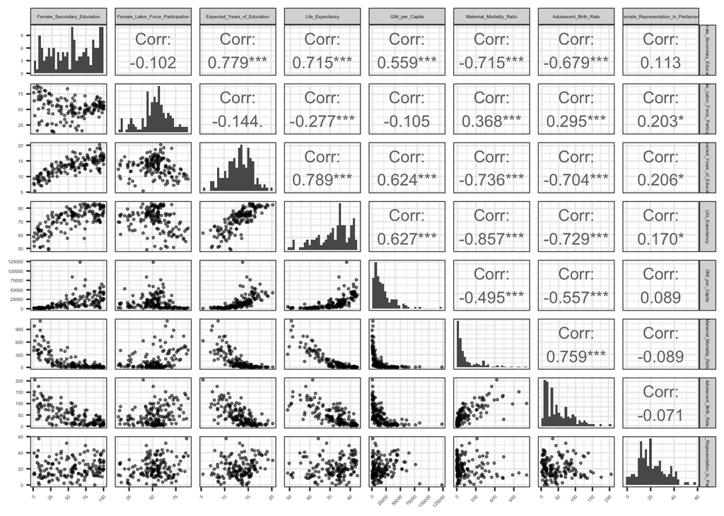

```r
# Creating an enhanced scatter plot matrix using GGally
library(GGally)

# Since I've already set country names as row names, I'll drop the row names because ggpairs expects a data frame without row names.
human_no_rownames <- human
rownames(human_no_rownames) <- NULL

# Using ggpairs to create the scatter plot matrix (I'm using ggpairs over basic plot functions to efficiently visualize the pairwise relationships and distribution of each variable, facilitating a comprehensive initial assessment.)
ggpairs(human_no_rownames,
        lower = list(continuous = wrap("points", size = 0.5, alpha = 0.5)),
        upper = list(continuous = wrap("cor", size = 4)),
        diag = list(continuous = wrap("barDiag")),
        axis.labels = 'show',
        axis.label.size = 2,
        legend.size = 5
) +
  theme_bw() +
  theme(
    text = element_text(size = 4),
    axis.text.x = element_text(angle = 45, hjust = 1)  # Rotating the x axis labels for better visibility
  )
```

**Observations**:

- **Expected Years of Education and Life Expectancy**: There’s a strong positive correlation (0.789), suggesting countries with higher education expectations tend to have higher life expectancies.
- **Maternal Mortality Ratio and Adolescent Birth Rate**: Both show strong negative correlations with Life Expectancy and Expected Years of Education, indicating that higher maternal and adolescent birth rates are associated with lower life expectancy and educational attainment.
- **Female Labor Force Participation**: The correlation with other variables is weaker, indicating that female labor force participation might be influenced by factors not captured by the other variables in this dataset.
- **GNI per Capita**: There’s a moderate positive correlation with Expected Years of Education and Life Expectancy, which aligns with the notion that higher national income levels can support better education and health outcomes.